# MA-331 Final

Kevin Ha, Connor Haaf, Ari Birnbaum

12/14/2021

# Final Project Write Up

## Executive Summary

The aim of this study is to look further into the interplay between two chemicals and their relation on bone growth and bone reduction. Specifically, we look at $OC$ and $TRAP$ then assess their impact alone and together on $VO+$ and $VO-$. As such, we run a number of statistical analysis and predictive models on these data to try to further understand their interplay.

## Study

As already stated, this is a study of interactions between $OC$ and $TRAP$ on bone growth and reduction. This is done over 31 data points of the values of $OC$, $TRAP$, bone growth ($VO+$) and reduction ($VO-$) for an individual. Additionally, due to some sort of skew or other imperfections in the given data, we perform these comparisons over the log of the data as well.

## Software

This analysis was written and produced using tools and libraries available through R, R Studio. R Markdown was used for producing LaTeX and graphical summaries.

## Methodology

In this study, we take in a set of 31 data points consisting of $VO+$, $VO-$, $OC$, $LOC$, $TRAP$, $LTRAP$, $LVO+$, and $LVO-$ (where $L$ means log). Based on the data in this set, we assess, through regression models, the strength of association between the various data. Additionally, based on the relations among the data types, we predict what changes we should see in one as we change another.

For each such prediction, we consider the quality of the prediction using a $t$ test and potential skewness with $qq$ plot analysis. Using all of these tools, we build a prediction and run it both on the linearly reduced data and the logarithmically mapped data through a linear reduction.

## **Conclusion**

In conclusion, after testing for the result of changing TRAP and or OC, we were able to conclude that there was indeed a significant correlation between bone formation and resorption with these changes. This change was a positive association, and the data set could have been larger to help work out the skew that we observed. In lieu of this, we took the log of the data to help normalize it and found that the correlation with OC increased by about 10%. Overall, we conclude that there is a correlation between this formation and resorption, and this would likely be better represented with a larger sample.

### 11.37

**a.**

**b.**

$TRAP_p=0.00158\lt OC_p=0.22102$. Since $TRAP$’s $p$-value is significantly lower than $OC$’s, $TRAP$ acts as a better predictor of bone formation, $VO+$.

This view is consistent with that of 11.36, since $TRAP$ had a smaller standard deviation of $6.5282397$ when compared with $OC$’s $19.6097441$. Thus, $TRAP$’s volatility was lower, meaning more consistent results.

### **11.38**

Based on the above table, the standard deviation for the estimated coefficients of the intercept, $OC$, and $TRAP$ are respectively $288.8035, 7.0965,\text{and } 24.4286$. While $OC$’s is the smallest, the intercept and $TRAP$’s coefficient prove to be very volatile between the three tables.

The same volatility is apparent in the $p$-values of the data set as well. Specifically, note the incredibly small $p$-values of 11.38’s $VO-$ and 11.37.a’s $OC$.

### 11.40

**For 11.37**

**a.**

**b.**

**For** **11.38**

**c.**

Based on the above table, the estimated coefficients for the intercept, $OC$, and $TRAP$ are far more stable when $VO+$ and $VO-$ are revered.

The same is apparent for the $p$-values of the data set as well.

### Problem 11.36

##### **Problem 11.36a**

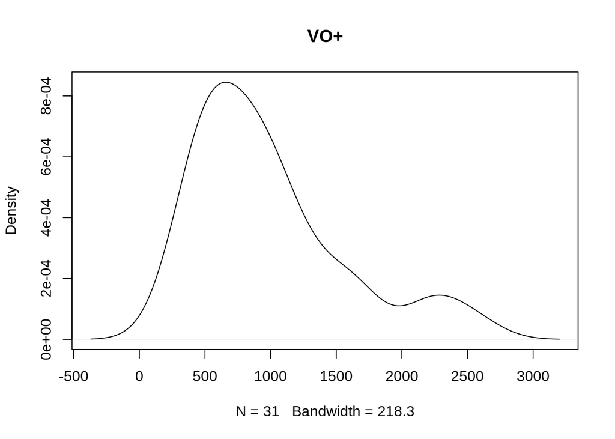

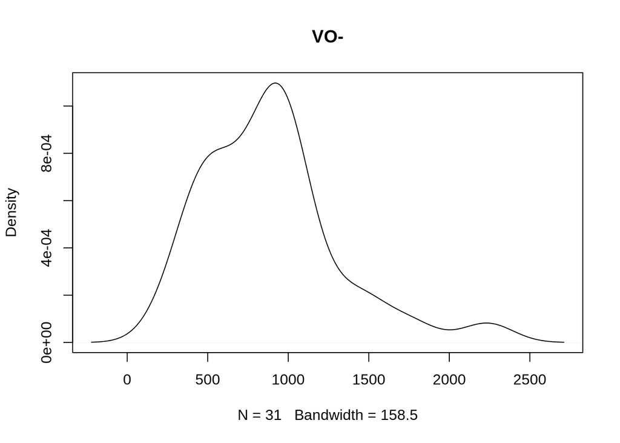

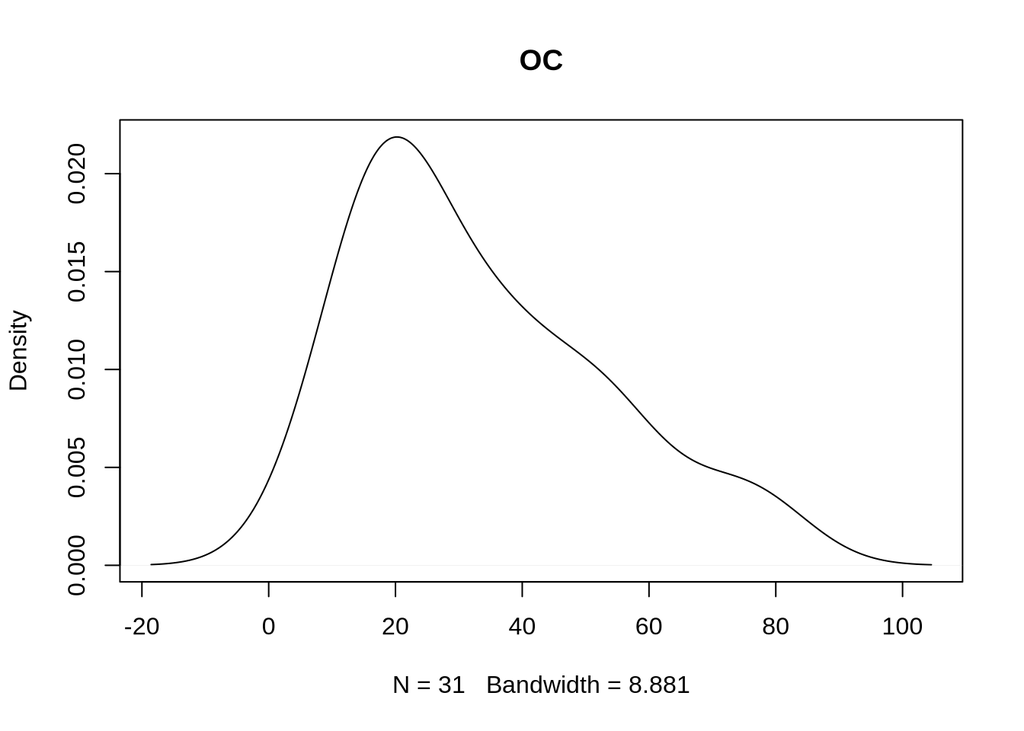

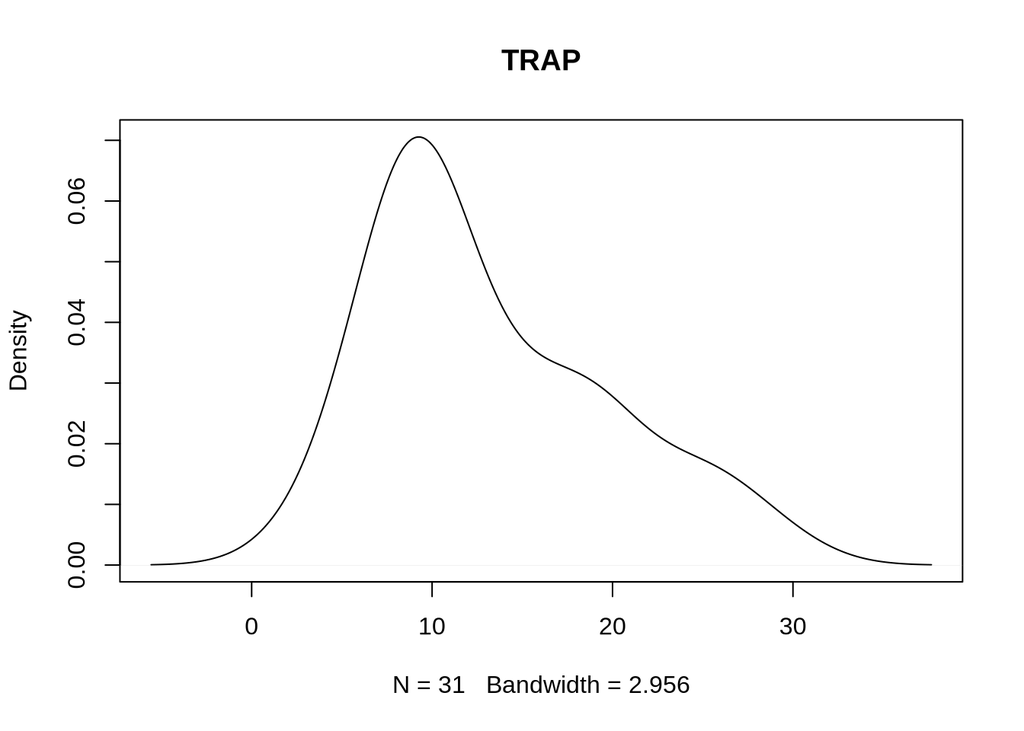

Numerical summary for VO+:

```
##    Min. 1st Qu.  Median    Mean 3rd Qu.    Max.
##   285.0   542.5   870.0   985.8  1188.5  2545.0
```

$s_{VO+}=579.8580527$

Numerical summary for VO-:

```
##    Min. 1st Qu.  Median    Mean 3rd Qu.    Max.
##   254.0   554.0   903.0   889.2  1023.0  2236.0
```

$s_{VO-}=427.6161378$

Numerical summary for OC:

```
##    Min. 1st Qu.  Median    Mean 3rd Qu.    Max.
##    8.10   18.60   30.20   33.42   46.05   77.90
```

$s_{OC}=19.6097441$

Numerical summary for TRAP:

```
##    Min. 1st Qu.  Median    Mean 3rd Qu.    Max.
##    3.30    8.90   10.30   13.25   18.80   28.80
```

$s_{TRAP}=6.5282397$

Graphical summary for all and the distribution: **Right skewed.**

##### **Problem 11.36b**

**Numerical summary:**

```
##            voplus   vominus        oc      trap
## voplus  1.0000000 0.8957707 0.6596140 0.7648649
## vominus 0.8957707 1.0000000 0.4547603 0.6779267
## oc      0.6596140 0.4547603 1.0000000 0.7298519
## trap    0.7648649 0.6779267 0.7298519 1.0000000
```

**Graphical Summary:**

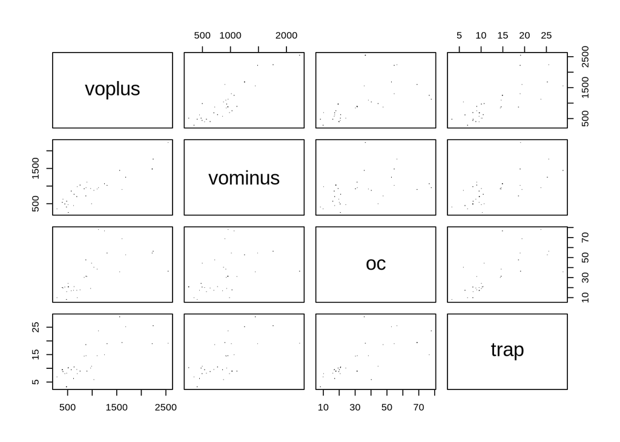

**All pairs exhibit a linear and positive association with varying strength as determined by their correlation numbers.**

### Problem 11.37

##### Problem 11.37a

```
##
## Call:
## lm(formula = voplus ~ oc, data = biomark)
##
## Residuals:
##     Min      1Q  Median      3Q     Max
## -727.45 -234.43  -85.08   43.66 1500.99
##
## Coefficients:
##             Estimate Std. Error t value Pr(>|t|)
## (Intercept)  334.034    159.241   2.098   0.0448 *
## oc            19.505      4.127   4.726 5.43e-05 ***
## ---
## Signif. codes:  0 '***' 0.001 '**' 0.01 '*' 0.05 '.' 0.1 ' ' 1
##
## Residual standard error: 443.3 on 29 degrees of freedom
## Multiple R-squared:  0.4351, Adjusted R-squared:  0.4156
## F-statistic: 22.34 on 1 and 29 DF,  p-value: 5.429e-05
```

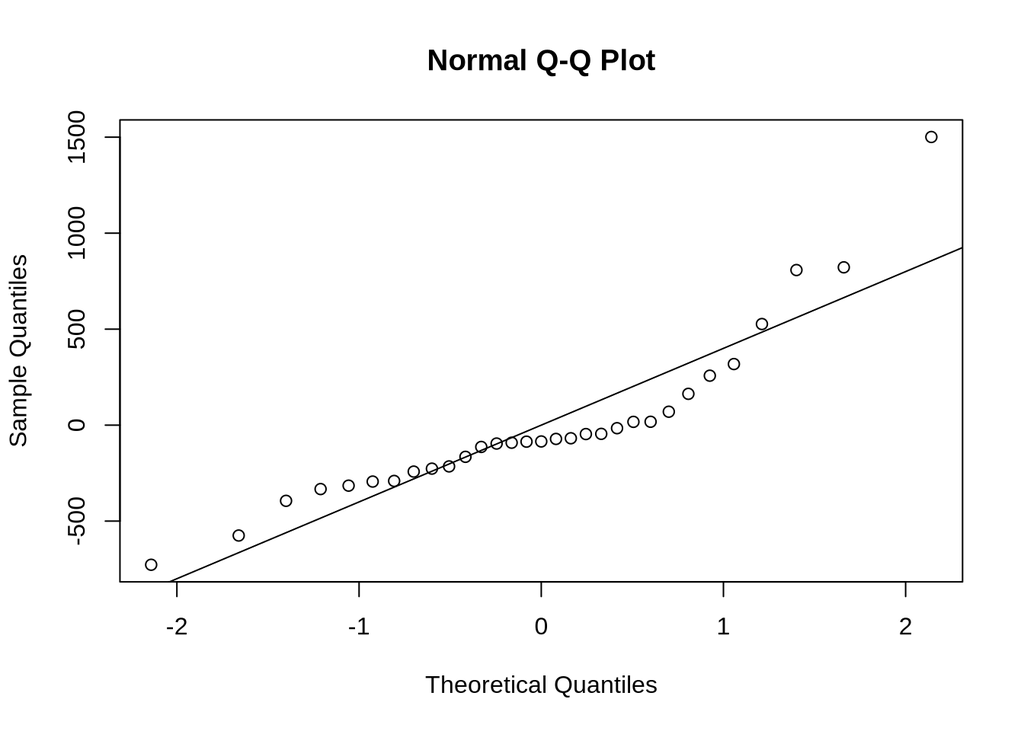

$VO+ = 334 + 19.51OC$

**The plot of residuals against OC is sightly curved.**

##### Problem 11.37b

```
##
## Call:
## lm(formula = voplus ~ oc + trap, data = biomark)
##
## Residuals:
##    Min     1Q Median     3Q    Max
## -708.2 -198.6 -100.2  125.8 1224.8
##
## Coefficients:
##             Estimate Std. Error t value Pr(>|t|)
## (Intercept)   57.704    156.539   0.369  0.71518
## oc             6.415      5.125   1.252  0.22102
## trap          53.874     15.393   3.500  0.00158 **
## ---
## Signif. codes:  0 '***' 0.001 '**' 0.01 '*' 0.05 '.' 0.1 ' ' 1
##
## Residual standard error: 376.3 on 28 degrees of freedom
## Multiple R-squared:  0.607,  Adjusted R-squared:  0.5789
## F-statistic: 21.62 on 2 and 28 DF,  p-value: 2.096e-06
```

$VO+ = 58 + 6.41OC + 53.9TRAP$

**The view that TRAP is a better predictor of bone formation than OC is consistent with the results from 11.36 as the p-value for TRAP is significantly lower than the p-value for OC.**

### Problem 11.38

##### Problem 11.38a

$y_{i} = \beta_0 + \beta_1x_{i1} + \beta_2x_{i2} + \beta_3x_{i1} + \epsilon_i$

OR

$VO+ = \beta_0 + \beta_1OC+ \beta_2TRAP + \beta_3VOMINUS + \epsilon_i$

**Assumption:** $\epsilon_i$ is assumed to be independent and $N(0, \sigma$)

##### Problem 11.38b

```
##
## Call:
## lm(formula = voplus ~ oc + trap + vominus, data = biomark)
##
## Residuals:
##     Min      1Q  Median      3Q     Max
## -364.19 -158.57  -15.13  120.08  441.11
##
## Coefficients:
##              Estimate Std. Error t value Pr(>|t|)
## (Intercept) -243.4877    94.2183  -2.584  0.01549 *
## oc             8.2349     2.8397   2.900  0.00733 **
## trap           6.6071    10.3340   0.639  0.52797
## vominus        0.9746     0.1211   8.048  1.2e-08 ***
## ---
## Signif. codes:  0 '***' 0.001 '**' 0.01 '*' 0.05 '.' 0.1 ' ' 1
##
## Residual standard error: 207.8 on 27 degrees of freedom
## Multiple R-squared:  0.8844, Adjusted R-squared:  0.8715
## F-statistic: 68.84 on 3 and 27 DF,  p-value: 9.031e-13
```

##### Problem 11.38c

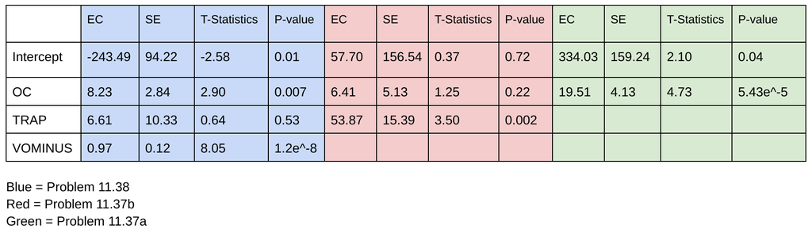

EC = Estimated Coefficient

SE = Standard Error

**The coefficients and P-values differ significantly between all three tables.**

##### Problem 11.38d

**11.37a:** Percent of variation is 43.51% (obtained from Multiple R-squared section in the summary) and the estimate of $\sigma = 443.3$

**11.37b:** Percent of variation is 60.7% (obtained from Multiple R-squared section in the summary) and the estimate of $\sigma = 376.3$

**11.38b:** Percent of variation is 88.44% (obtained from Multiple R-squared section in the summary) and the estimate of $\sigma = 207.8$

##### Problem 11.38e

*11.38b suggests that TRAP coefficient is not significant, so remove it.*

```
##
## Call:
## lm(formula = voplus ~ oc + vominus, data = biomark)
##
## Residuals:
##     Min      1Q  Median      3Q     Max
## -350.25 -153.94  -13.22  148.19  428.09
##
## Coefficients:
##               Estimate Std. Error t value Pr(>|t|)
## (Intercept) -234.14400   92.09009  -2.543 0.016818 *
## oc             9.40388    2.14964   4.375 0.000153 ***
## vominus        1.01857    0.09858  10.333 4.65e-11 ***
## ---
## Signif. codes:  0 '***' 0.001 '**' 0.01 '*' 0.05 '.' 0.1 ' ' 1
##
## Residual standard error: 205.6 on 28 degrees of freedom
## Multiple R-squared:  0.8826, Adjusted R-squared:  0.8742
## F-statistic: 105.3 on 2 and 28 DF,  p-value: 9.418e-14
```

$VO+ = -234.14 + 9.40OC + 1.02VO-$

**Better performance in terms of P-value compared to part B.**

### Problem 11.39

```
##         lvoplus  lvominus       loc     ltrap
## lvoplus       1 0.8396741 0.7735853 0.7549684
```

|  | *Dependent variable:* |  |  |  |
| --- | --- | --- | --- | --- |
|  | lvoplus |  |  |  |
|  | (1) | (2) | (3) | (4) |
| loc | 0.706 | 0.430 | 0.392 | 0.406 |
|  | p = 0.00000 | p = 0.017 | p = 0.003 | p = 0.00004 |
|  | t = 6.574*** | t = 2.560** | t = 3.398*** | t = 4.925*** |
| ltrap |  | 0.424 | 0.028 |  |
|  |  | p = 0.049 | p = 0.862 |  |
|  |  | t = 2.066** | t = 0.176 |  |
| lvominus |  |  | 0.673 | 0.682 |
|  |  |  | p = 0.00001 | p = 0.00000 |
|  |  |  | t = 5.710*** | t = 6.569*** |
| Constant | 4.385 | 4.259 | 0.872 | 0.832 |
|  | p = 0.000 | p = 0.000 | p = 0.185 | p = 0.169 |
|  | t = 12.036*** | t = 12.147*** | t = 1.361 | t = 1.413 |
| Observations | 31 | 31 | 31 | 31 |
| R<sup>2</sup> | 0.598 | 0.652 | 0.842 | 0.842 |
| Adjusted R<sup>2</sup> | 0.585 | 0.627 | 0.825 | 0.831 |
| Residual Std. Error | 0.358 (df = 29) | 0.339 (df = 28) | 0.233 (df = 27) | 0.229 (df = 28) |
| F Statistic | 43.217*** (df = 1; 29) | 26.178*** (df = 2; 28) | 48.015*** (df = 3; 27) | 74.588*** (df = 2; 28) |
| *Note:* | p<0.1; p<0.05; p<0.01 |  |  |  |

$LVO+ = 4.38 + 0.706LOC$

$LVO+ = 4.26 + 0.430LOC + 0.424LTRAP$

$LVO+ = 0.872 + 0.392LOC + 0.028LTRAP + 0.673LVO-$

Model without LTRAP since it is insignificant (#4 in the table above):

$LVO+ = 0.832 + 0.406LOC + 0.682LVO-$

### Problem 11.40

**11.36:**

```
##         vominus    voplus        oc      trap
## vominus       1 0.8957707 0.4547603 0.6779267
```

(Graphs remain the same and other numerical summaries remain the same)

**11.37: (#1 is Part A, #2 is Part B)**

|  | *Dependent variable:* |  |
| --- | --- | --- |
|  | vominus |  |
|  | (1) | (2) |
| oc | 9.917 | -1.868 |
|  | p = 0.011 | p = 0.676 |
|  | t = 2.750** | t = -0.423 |
| trap |  | 48.501 |
|  |  | p = 0.002 |
|  |  | t = 3.655*** |
| Constant | 557.818 | 309.051 |
|  | p = 0.0004 | p = 0.030 |
|  | t = 4.009*** | t = 2.290** |
| Observations | 31 | 31 |
| R<sup>2</sup> | 0.207 | 0.463 |
| Adjusted R<sup>2</sup> | 0.179 | 0.425 |
| Residual Std. Error | 387.351 (df = 29) | 324.353 (df = 28) |
| F Statistic | 7.561** (df = 1; 29) | 12.071*** (df = 2; 28) |
| *Note:* | p<0.1; p<0.05; p<0.01 |  |

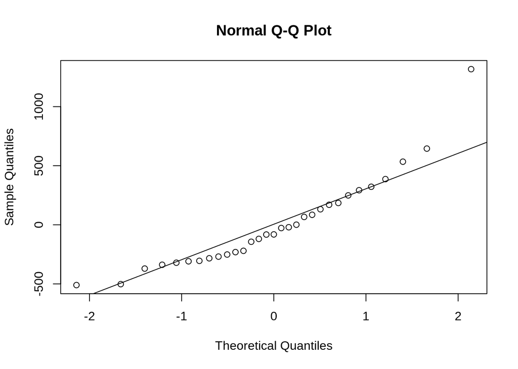

**The plot of residuals against OC is sightly curved again.**

$VO- = 557.82 + 9.92OC$ (Part A)

$VO- = 309.05 - 1.87OC + 48.5TRAP$ (Part B)

**11.38 (#1 is Part B, #2 is Part E)**

|  | *Dependent variable:* |  |
| --- | --- | --- |
|  | vominus |  |
|  | (1) | (2) |
| oc | -6.513 | -5.254 |
|  | p = 0.016 | p = 0.026 |
|  | t = -2.598** | t = -2.360** |
| trap | 9.485 |  |
|  | p = 0.291 |  |
|  | t = 1.079 |  |
| voplus | 0.724 | 0.778 |
|  | p = 0.000 | p = 0.000 |
|  | t = 8.048*** | t = 10.333*** |
| Constant | 267.261 | 298.012 |
|  | p = 0.002 | p = 0.0002 |
|  | t = 3.577*** | t = 4.302*** |
| Observations | 31 | 31 |
| R<sup>2</sup> | 0.842 | 0.835 |
| Adjusted R<sup>2</sup> | 0.824 | 0.823 |
| Residual Std. Error | 179.162 (df = 27) | 179.688 (df = 28) |
| F Statistic | 47.966*** (df = 3; 27) | 70.949*** (df = 2; 28) |
| *Note:* | p<0.1; p<0.05; p<0.01 |  |

$VO- = 267.26 - 6.51OC + 9.48TRAP + 0.72VO+$ (Part B)

### Problem 11.41

**11.36:**

```
##          lvominus   lvoplus      loc     ltrap
## lvominus        1 0.8396741 0.554607 0.6643005
```

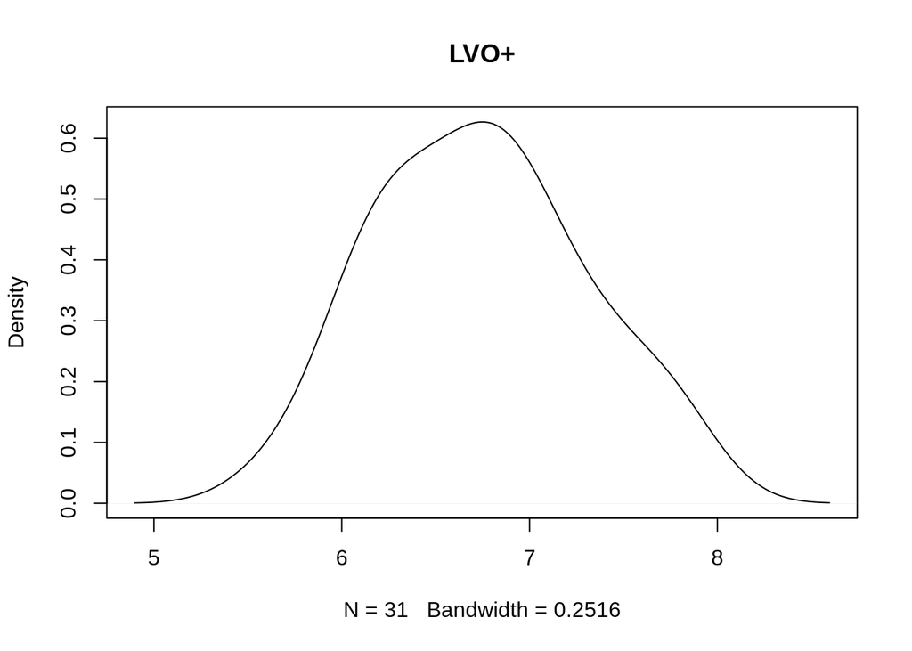

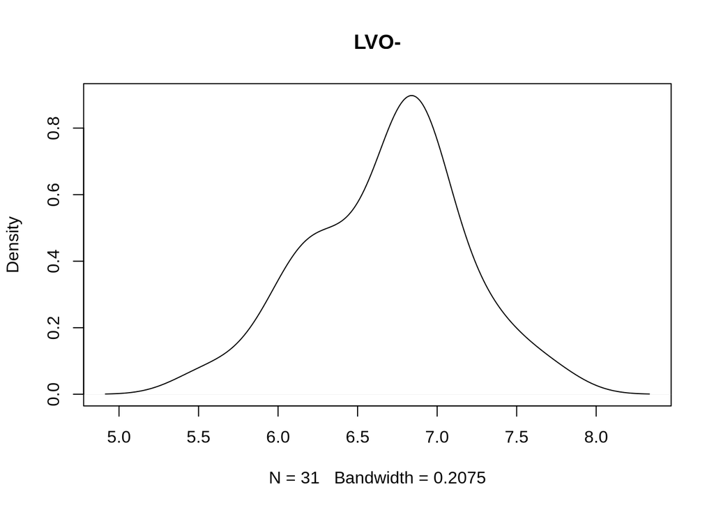

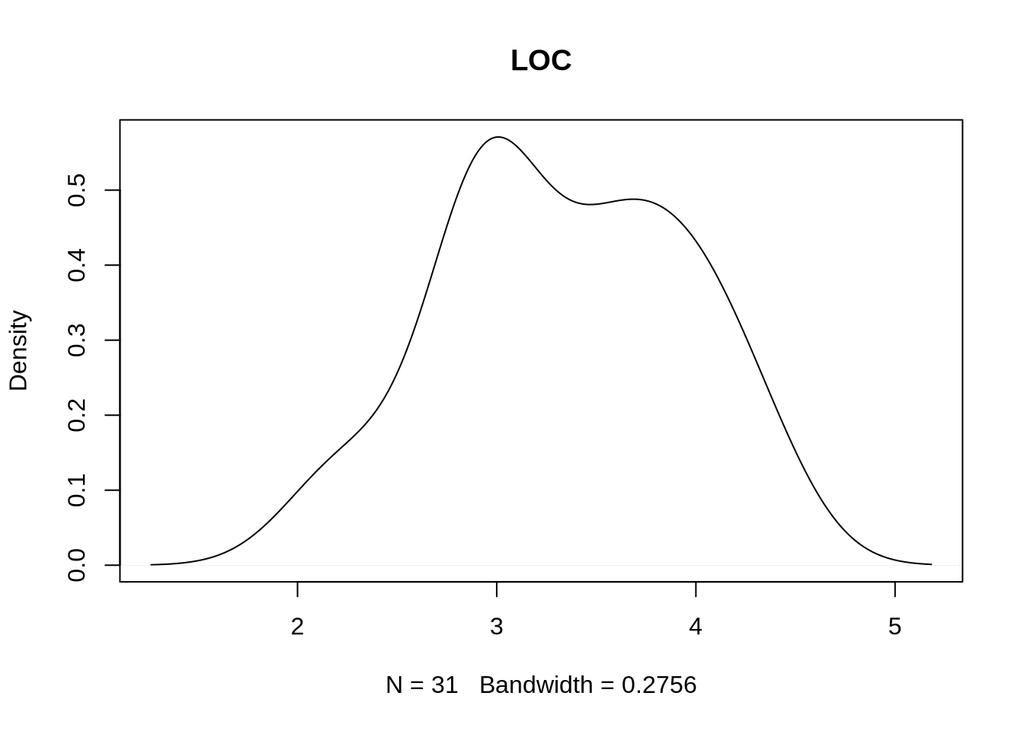

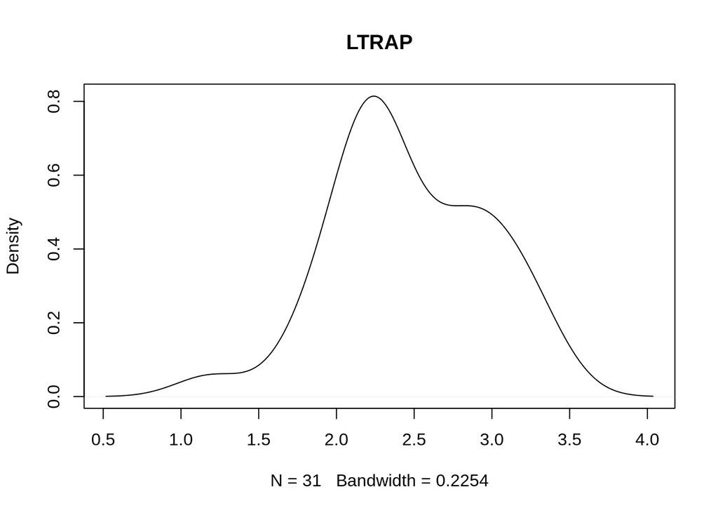

**Slight left skew when compared to the non-logarithmic versions of the graph**

Numerical summary for LVO+:

```
##    Min. 1st Qu.  Median    Mean 3rd Qu.    Max.
##   5.652   6.295   6.768   6.742   7.079   7.842
```

$s_{LVO+}=0.5554948$

Numerical summary for LVO-:

```
##    Min. 1st Qu.  Median    Mean 3rd Qu.    Max.
##   5.537   6.316   6.806   6.682   6.931   7.712
```

$s_{LVO-}=0.4832368$

Numerical summary for LOC:

```
##    Min. 1st Qu.  Median    Mean 3rd Qu.    Max.
##   2.092   2.922   3.408   3.338   3.829   4.355
```

$s_{LOC}=0.6085089$

Numerical summary for LTRAP:

```
##    Min. 1st Qu.  Median    Mean 3rd Qu.    Max.
##   1.194   2.186   2.332   2.467   2.933   3.360
```

$s_{LTRAP}=0.4978053$

**11.37: (#1 is Part A, #2 is Part B)**

|  | *Dependent variable:* |  |
| --- | --- | --- |
|  | lvominus |  |
|  | (1) | (2) |
| loc | 0.440 | 0.057 |
|  | p = 0.002 | p = 0.762 |
|  | t = 3.589*** | t = 0.307 |
| ltrap |  | 0.590 |
|  |  | p = 0.015 |
|  |  | t = 2.611** |
| Constant | 5.211 | 5.037 |
|  | p = 0.000 | p = 0.000 |
|  | t = 12.524*** | t = 13.063*** |
| Observations | 31 | 31 |
| R<sup>2</sup> | 0.308 | 0.443 |
| Adjusted R<sup>2</sup> | 0.284 | 0.403 |
| Residual Std. Error | 0.409 (df = 29) | 0.373 (df = 28) |
| F Statistic | 12.883*** (df = 1; 29) | 11.142*** (df = 2; 28) |
| *Note:* | p<0.1; p<0.05; p<0.01 |  |

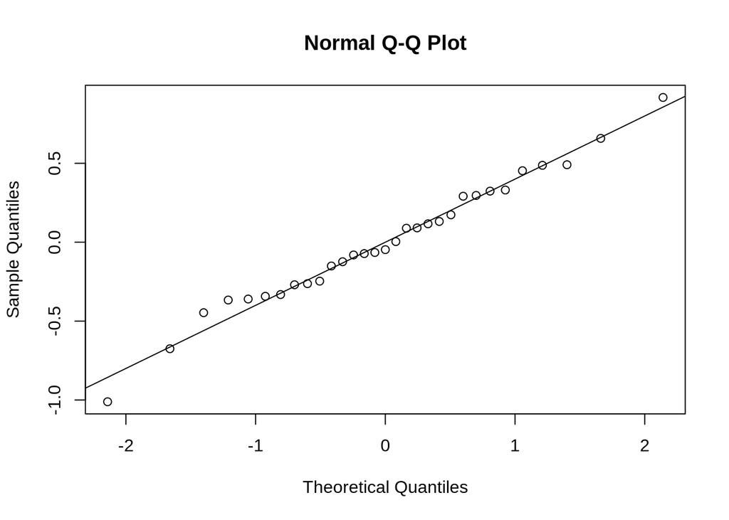

$LVO- = 5.21 + 0.44LOC$ (Part A)

$LVO- = 5.04 - 0.06LOC + 0.59LTRAP$ (Part B)

**11.38 (#1 is Part B, #2 is Part E)**

|  | *Dependent variable:* |  |
| --- | --- | --- |
|  | lvominus |  |
|  | (1) | (2) |
| loc | -0.293 | -0.188 |
|  | p = 0.047 | p = 0.141 |
|  | t = -2.083** | t = -1.519 |
| ltrap | 0.245 |  |
|  | p = 0.153 |  |
|  | t = 1.472 |  |
| lvoplus | 0.813 | 0.890 |
|  | p = 0.00001 | p = 0.00000 |
|  | t = 5.710*** | t = 6.569*** |
| Constant | 1.573 | 1.311 |
|  | p = 0.025 | p = 0.054 |
|  | t = 2.377** | t = 2.015* |
| Observations | 31 | 31 |
| R<sup>2</sup> | 0.748 | 0.728 |
| Adjusted R<sup>2</sup> | 0.720 | 0.708 |
| Residual Std. Error | 0.256 (df = 27) | 0.261 (df = 28) |
| F Statistic | 26.679*** (df = 3; 27) | 37.377*** (df = 2; 28) |
| *Note:* | p<0.1; p<0.05; p<0.01 |  |

$LVO- = 1.57 - 0.29LOC + 0.25LTRAP + 0.81LVO+$ (Part B)

$LVO- = 1.31 - 0.19LOC + 0.89LVO+$ (Part E)